# simple linearregression

Advantages Easy to interpret: Simple and intuitive representation of relationships between two variables.

Efficient computation: Requires minimal computational resources compared to more complex models.

Widely applicable: Suitable for many real-world scenarios with linear relationships.

Good for initial analysis: Serves as a baseline model for understanding variable relationships.

Disadvantages Assumes linearity: Ineffective if the relationship between variables is non-linear.

Sensitive to outliers: Outliers can significantly skew results and reduce model accuracy.

Limited flexibility: Can only analyze the relationship between one dependent and one independent variable.

Does not account for confounding variables: Ignores potential external factors that influence outcomes.

Key Assumptions Linearity: The relationship between x and y is linear. Independence: Observations are independent of each other. Homoscedasticity: Constant variance of errors across all values of x. Normality: Residuals (errors) follow a normal distribution.

```
   cgpa  package
0  6.89     3.26
1  5.12     1.98
2  7.82     3.25
3  7.42     3.67
4  6.94     3.57
```

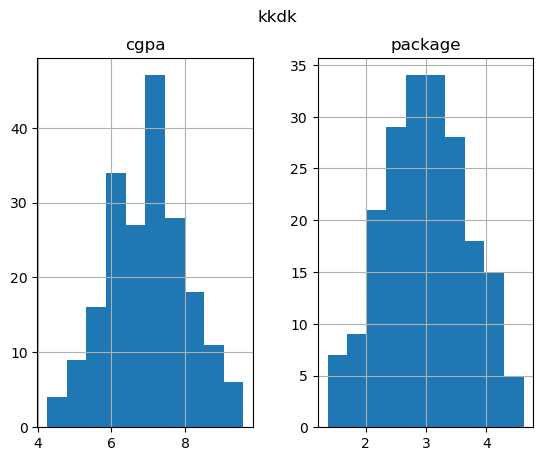

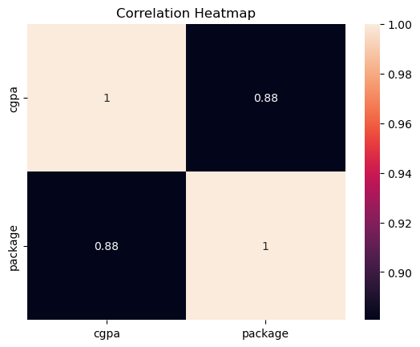

```
Mean Squared Error: 0.08417638361329657
R-squared: 0.7730984312051673
```

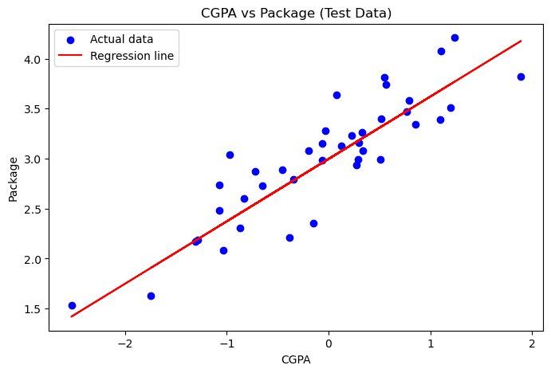

```python
# Step 1: Import necessary libraries
import pandas as pd
import numpy as np
import matplotlib.pyplot as plt
import seaborn as sns
from sklearn.model_selection import train_test_split
from sklearn.preprocessing import StandardScaler
from sklearn.linear_model import LinearRegression
from sklearn.metrics import mean_squared_error, r2_score


df = pd.read_csv('placement.csv')
print(df.head())

df.hist()
plt.suptitle('kkdk')
plt.show()


sns.heatmap(df.corr(), annot=True)
plt.title('Correlation Heatmap')
plt.show()

# Step 4: Feature encoding, splitting, and scaling
# In this case, we don't need encoding since 'CGPA' and 'Package' are numerical columns.
X = df[['cgpa']]  # Feature
y = df['package']  # Target

# Split data into training and testing sets
X_train, X_test, y_train, y_test = train_test_split(X, y, test_size=0.2, random_state=42)

# Feature scaling
scaler = StandardScaler()
X_train = scaler.fit_transform(X_train)
X_test = scaler.transform(X_test)

# Step 5: Model Training and Prediction
model = LinearRegression()
model.fit(X_train, y_train)

# Predict on test set
y_pred = model.predict(X_test)

# Step 6: Performance Metrics
# Calculate Mean Squared Error and R-squared
mse = mean_squared_error(y_test, y_pred)
r2 = r2_score(y_test, y_pred)

print(f"Mean Squared Error: {mse}")
print(f"R-squared: {r2}")

# Plotting the regression line
plt.figure(figsize=(8, 5))
plt.scatter(X_test, y_test, color='blue', label='Actual data')
plt.plot(X_test, y_pred, color='red', label='Regression line')
plt.title('CGPA vs Package (Test Data)')
plt.xlabel('CGPA')
plt.ylabel('Package')
plt.legend()
plt.show()
```